# Rental Pricing in KL

Ken Law

2023-02-27

# Rental Prices in Kuala Lumpur (02/12/2023)

## Description

This dataset is provided by ARIEWIJAYA on Kaggle. It is scraped from local rental advertising listing websites in Kuala Lumpur. It contains a few listings from the surrounding outskirt areas of KL. There are 9991 listings total with 13 variables. Primary key is set as ‘ads_id’ by the dataset owner.

## Variables

1. Advertising ID: Unique ID assigned to each *primary key*
2. Property name: (Character)
3. Completion year: (Date/Integer)
4. Monthly rent: Currency in Ringgit Malaysia (Currency/Numeric)
5. Location: ‘City - Region’ (Location/Character)
6. Property Type: Categorical e.g. Apartment, Condo (Factor)
7. Rooms: (Integer)
8. Parking: (Integer)
9. Bathroom: (Integer)
10. Size: Calculated in sq. ft. (Integer)
11. Furnished: Fully, Partially, or Not Furnished (Factor)
12. Facilities: Listed amenities and facilities provided (Factor)
13. Additional Facilities: Air-con, Public Transport, etc (Factor)

## Business Task

**Market Analysis:**  
Analyze the location, property type, size, and completion year columns to understand the current market trends and demand for specific types of properties in certain areas.

**Pricing Optimization:**  
Use the completion year, location, property type, size, furnished, and facilities columns to determine the optimal price for a property.

**Customer Segmentation:**  
Analyze the facilities and additional facilities columns to identify patterns in customer preferences and segment the market accordingly.

**Property Selection:**  
Use the completion year, location, property type, size, furnished, facilities, parking, bathroom, and rooms columns to identify properties that meet specific customer needs and preferences.

**Advertising and Marketing:**  
Use the advertising ID, property name, completion year, location, property type, size, furnished, and facilities columns to create targeted advertising campaigns and marketing strategies.

**Inventory Management:**  
Use the furnished column to track which properties are fully, partially, or not furnished and manage inventory accordingly.

**Maintenance and Improvement:**  
Use the completion year and facilities columns to identify areas where improvements or maintenance may be needed to keep the property competitive in the market.

**Revenue Forecasting:**  
Use the monthly rent and size columns to forecast potential revenue and evaluate the profitability of a rental property.

**Performance Tracking:**  
Use the monthly rent, size, parking, bathroom, and rooms columns to track the performance of a property over time and identify areas for improvement.

**Risk Assessment:**  
Use the location, completion year, and property type columns to assess the risk of investing in a specific property.

## Data Processing

Loading the packages:

```r
library(here)
library(tidyverse)
library(dplyr)
library(readr)
library(stringr)
library(janitor)
library(skimr)
```

Open CSV file:

```r
mudah_apartment_clean <- read_csv("C:/Users/lawke/Desktop/portfolio_2023/rental-pricing-in-kuala-lumpur-malaysia/mudah-apartment-clean.csv")
```

Quick look:

```r
skim_without_charts(mudah_apartment_clean)
```

Data summary

| Name | mudah_apartment_clean |
| --- | --- |
| Number of rows | 9991 |
| Number of columns | 13 |
| _______________________ |  |
| Column type frequency: |  |
| character | 8 |
| numeric | 5 |
| ________________________ |  |
| Group variables | None |

**Variable type: character**

| skim_variable | n_missing | complete_rate | min | max | empty | n_unique | whitespace |
| --- | --- | --- | --- | --- | --- | --- | --- |
| prop_name | 508 | 0.95 | 3 | 82 | 0 | 1292 | 0 |
| monthly_rent | 0 | 1.00 | 15 | 22 | 0 | 273 | 0 |
| location | 0 | 1.00 | 18 | 35 | 0 | 60 | 0 |
| property_type | 0 | 1.00 | 4 | 50 | 0 | 10 | 0 |
| size | 0 | 1.00 | 8 | 15 | 0 | 931 | 0 |
| furnished | 1 | 1.00 | 13 | 19 | 0 | 3 | 0 |
| facilities | 895 | 0.91 | 4 | 167 | 0 | 5981 | 0 |
| additional_facilities | 2831 | 0.72 | 8 | 68 | 0 | 145 | 0 |

**Variable type: numeric**

| skim_variable | n_missing | complete_rate | mean | sd | p0 | p25 | p50 | p75 | p100 |
| --- | --- | --- | --- | --- | --- | --- | --- | --- | --- |
| ads_id | 0 | 1.00 | 99364754.80 | 4005482.88 | 16525511 | 99753474 | 99932996 | 100147960 | 100323185 |
| completion_year | 4373 | 0.56 | 2014.81 | 7.42 | 1980 | 2011 | 2017 | 2020 | 2025 |
| rooms | 4 | 1.00 | 2.76 | 0.78 | 1 | 2 | 3 | 3 | 9 |
| parking | 2630 | 0.74 | 1.35 | 0.53 | 1 | 1 | 1 | 2 | 10 |
| bathroom | 2 | 1.00 | 1.95 | 0.58 | 1 | 2 | 2 | 2 | 7 |

```r
glimpse(mudah_apartment_clean)
```

```
## Rows: 9,991
## Columns: 13
## $ ads_id                <dbl> 100323185, 100203973, 100323128, 100191767, 9702…
## $ prop_name             <chr> "The Hipster @ Taman Desa", "Segar Courts", "Pan…
## $ completion_year       <dbl> 2022, NA, NA, 2020, NA, NA, NA, 2018, 2014, NA, …
## $ monthly_rent          <chr> "RM 4 200 per month", "RM 2 300 per month", "RM …
## $ location              <chr> "Kuala Lumpur - Taman Desa", "Kuala Lumpur - Che…
## $ property_type         <chr> "Condominium", "Condominium", "Apartment", "Apar…
## $ rooms                 <dbl> 5, 3, 3, 2, 1, 3, 3, 1, 2, 3, 2, 4, 1, 3, 5, 3, …
## $ parking               <dbl> 2, 1, NA, 1, 1, 1, 2, 1, 1, 1, NA, 2, 1, 1, NA, …
## $ bathroom              <dbl> 6, 2, 2, 2, 1, 2, 2, 1, 1, 2, 2, 2, 1, 2, 2, 2, …
## $ size                  <chr> "1842 sq.ft.", "1170 sq.ft.", "650 sq.ft.", "743…
## $ furnished             <chr> "Fully Furnished", "Partially Furnished", "Fully…
## $ facilities            <chr> "Minimart, Gymnasium, Security, Playground, Swim…
## $ additional_facilities <chr> "Air-Cond, Cooking Allowed, Washing Machine", "A…
```

```r
head(mudah_apartment_clean)
```

```
## # A tibble: 6 × 13
##      ads_id prop_n…¹ compl…² month…³ locat…⁴ prope…⁵ rooms parking bathr…⁶ size
##       <dbl> <chr>      <dbl> <chr>   <chr>   <chr>   <dbl>   <dbl>   <dbl> <chr>
## 1 100323185 The Hip…    2022 RM 4 2… Kuala … Condom…     5       2       6 1842…
## 2 100203973 Segar C…      NA RM 2 3… Kuala … Condom…     3       1       2 1170…
## 3 100323128 Pangsap…      NA RM 1 0… Kuala … Apartm…     3      NA       2 650 …
## 4 100191767 Sentul …    2020 RM 1 7… Kuala … Apartm…     2       1       2 743 …
## 5  97022692 Arte Mo…      NA RM 1 2… Kuala … Servic…     1       1       1 494 …
## 6 100322897 Residen…      NA RM 1 5… Kuala … Apartm…     3       1       2 884 …
## # … with 3 more variables: furnished <chr>, facilities <chr>,
## #   additional_facilities <chr>, and abbreviated variable names ¹prop_name,
## #   ²completion_year, ³monthly_rent, ⁴location, ⁵property_type, ⁶bathroom
```

```r
str(mudah_apartment_clean)
```

```
## spc_tbl_ [9,991 × 13] (S3: spec_tbl_df/tbl_df/tbl/data.frame)
##  $ ads_id               : num [1:9991] 1.0e+08 1.0e+08 1.0e+08 1.0e+08 9.7e+07 ...
##  $ prop_name            : chr [1:9991] "The Hipster @ Taman Desa" "Segar Courts" "Pangsapuri Teratak Muhibbah 2" "Sentul Point Suite Apartment" ...
##  $ completion_year      : num [1:9991] 2022 NA NA 2020 NA ...
##  $ monthly_rent         : chr [1:9991] "RM 4 200 per month" "RM 2 300 per month" "RM 1 000 per month" "RM 1 700 per month" ...
##  $ location             : chr [1:9991] "Kuala Lumpur - Taman Desa" "Kuala Lumpur - Cheras" "Kuala Lumpur - Taman Desa" "Kuala Lumpur - Sentul" ...
##  $ property_type        : chr [1:9991] "Condominium" "Condominium" "Apartment" "Apartment" ...
##  $ rooms                : num [1:9991] 5 3 3 2 1 3 3 1 2 3 ...
##  $ parking              : num [1:9991] 2 1 NA 1 1 1 2 1 1 1 ...
##  $ bathroom             : num [1:9991] 6 2 2 2 1 2 2 1 1 2 ...
##  $ size                 : chr [1:9991] "1842 sq.ft." "1170 sq.ft." "650 sq.ft." "743 sq.ft." ...
##  $ furnished            : chr [1:9991] "Fully Furnished" "Partially Furnished" "Fully Furnished" "Partially Furnished" ...
##  $ facilities           : chr [1:9991] "Minimart, Gymnasium, Security, Playground, Swimming Pool, Parking, Lift, Barbeque area, Multipurpose hall, Jogging Track" "Playground, Parking, Barbeque area, Security, Jogging Track, Swimming Pool, Gymnasium, Lift, Sauna" "Minimart, Jogging Track, Lift, Sw…
##  $ additional_facilities: chr [1:9991] "Air-Cond, Cooking Allowed, Washing Machine" "Air-Cond, Cooking Allowed, Near KTM/LRT" NA "Cooking Allowed, Near KTM/LRT, Washing Machine" ...
##  - attr(*, "spec")=
##   .. cols(
##   ..   ads_id = col_double(),
##   ..   prop_name = col_character(),
##   ..   completion_year = col_double(),
##   ..   monthly_rent = col_character(),
##   ..   location = col_character(),
##   ..   property_type = col_character(),
##   ..   rooms = col_double(),
##   ..   parking = col_double(),
##   ..   bathroom = col_double(),
##   ..   size = col_character(),
##   ..   furnished = col_character(),
##   ..   facilities = col_character(),
##   ..   additional_facilities = col_character()
##   .. )
##  - attr(*, "problems")=<externalptr>
```

Split location into city and region:

```r
mudah_apartment_clean <- mudah_apartment_clean %>%
  mutate(city = str_split(location, "-", simplify = TRUE)[, 1],
         region = str_split(location, "-", simplify = TRUE)[, 2]) %>% select(-location)
```

## Data Validation

```r
class(mudah_apartment_clean$prop_name)
```

```
## [1] "character"
```

```r
class(mudah_apartment_clean$completion_year)
```

```
## [1] "numeric"
```

```r
class(mudah_apartment_clean$monthly_rent)
```

```
## [1] "character"
```

```r
class(mudah_apartment_clean$city)
```

```
## [1] "character"
```

```r
class(mudah_apartment_clean$region)
```

```
## [1] "character"
```

```r
class(mudah_apartment_clean$rooms)
```

```
## [1] "numeric"
```

```r
class(mudah_apartment_clean$parking)
```

```
## [1] "numeric"
```

```r
class(mudah_apartment_clean$bathroom)
```

```
## [1] "numeric"
```

```r
class(mudah_apartment_clean$size)
```

```
## [1] "character"
```

```r
class(mudah_apartment_clean$furnished)
```

```
## [1] "character"
```

```r
class(mudah_apartment_clean$facilities)
```

```
## [1] "character"
```

```r
class(mudah_apartment_clean$additional_facilities)
```

```
## [1] "character"
```

## Data Cleaning and Transformation

Convert monthly_rent (character to numeric):

```r
mudah_apartment_clean <- mudah_apartment_clean %>%
  mutate(monthly_rent = as.integer(str_replace_all(mudah_apartment_clean$monthly_rent, c("RM" = "", "per" = "", "month" = "", " " = ""))))


class(mudah_apartment_clean$monthly_rent)
```

```
## [1] "integer"
```

Convert size (character to integer):

```r
mudah_apartment_clean <- mudah_apartment_clean %>%
  mutate(size = as.integer((str_remove(size, "sq.ft."))))
class(mudah_apartment_clean$size)
```

```
## [1] "integer"
```

Convert furnished (character to factor):

```r
mudah_apartment_clean <- mudah_apartment_clean %>%
  mutate(furnished = as.factor(furnished))
class(mudah_apartment_clean$furnished)
```

```
## [1] "factor"
```

Remove Properties with no names (NA):

```r
mudah_apartment_clean <- subset(mudah_apartment_clean, !is.na(mudah_apartment_clean$prop_name))
```

# Analysis

Which regions in KL are the most expensive?

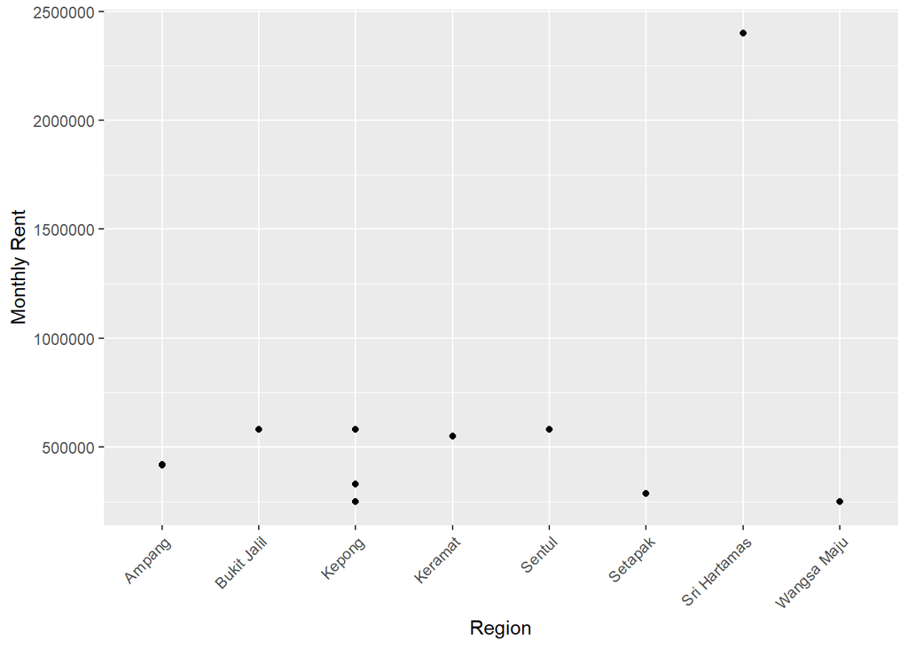

```r
expensive_region <-  subset(mudah_apartment_clean, monthly_rent > 200000)
ggplot(data = expensive_region, aes(x = expensive_region$region , y = expensive_region$monthly_rent)) +
  geom_point() +
  theme(axis.text.x = element_text(angle = 45, hjust = 1)) +
  labs(x = "Region", y = "Monthly Rent")
```

Which rental properties have the highest rent?

```r
mudah_apartment_clean <- mudah_apartment_clean %>%  arrange(desc(monthly_rent))
head(mudah_apartment_clean)
```

```
## # A tibble: 6 × 14
##      ads_id prop_n…¹ compl…² month…³ prope…⁴ rooms parking bathr…⁵  size furni…⁶
##       <dbl> <chr>      <dbl>   <int> <chr>   <dbl>   <dbl>   <dbl> <int> <fct>
## 1 100058432 Sunway …    2011 2400000 Condom…     4       3       4  2573 Fully …
## 2 100223741 The Tam…    2005  580000 Condom…     4       1       3  1345 Fully …
## 3  99990155 United …    2019  580000 Servic…     3       2       2   958 Fully …
## 4  99812277 Parkhil…    2019  580000 Condom…     3       2       2  1100 Fully …
## 5  99812339 The Hau…    2019  550000 Condom…     3       2       2  1061 Partia…
## 6  99888010 The Ele…    2015  419000 Servic…     1       1       1   705 Partia…
## # … with 4 more variables: facilities <chr>, additional_facilities <chr>,
## #   city <chr>, region <chr>, and abbreviated variable names ¹prop_name,
## #   ²completion_year, ³monthly_rent, ⁴property_type, ⁵bathroom, ⁶furnished
```

> 1. Sunway Vivaldi = RM 2,400,000
> 2. The Tamarind = RM 580,000
> 3. United Point Residence @ North Kiara = RM 580,000
> 4. Parkhill Residence Bukit Jalil = RM 580,000
> 5. The Haute = RM 550,000
> - Monthly rent

Which rental properties have the lowest rent?

```r
tail(mudah_apartment_clean)
```

```
## # A tibble: 6 × 14
##      ads_id prop_n…¹ compl…² month…³ prope…⁴ rooms parking bathr…⁵  size furni…⁶
##       <dbl> <chr>      <dbl>   <int> <chr>   <dbl>   <dbl>   <dbl> <int> <fct>
## 1 100183866 Melur A…    2006     100 Apartm…     1      NA       1   100 Not Fu…
## 2 100163744 Platinu…      NA     100 Condom…     1       1       1     1 Not Fu…
## 3 100129853 Platinu…    2013     100 Condom…     1      NA       1   100 Not Fu…
## 4  99872270 Platinu…      NA     100 Condom…     1      NA       1   500 Not Fu…
## 5  99974016 Idaman …      NA      90 Condom…     1       1       1   100 Not Fu…
## 6  99410613 Setapak…    1994      80 Condom…     1      NA       1     5 Not Fu…
## # … with 4 more variables: facilities <chr>, additional_facilities <chr>,
## #   city <chr>, region <chr>, and abbreviated variable names ¹prop_name,
## #   ²completion_year, ³monthly_rent, ⁴property_type, ⁵bathroom, ⁶furnished
```

> 1. Setapak Ria Condo = RM 80
> 2. Idaman Sutera = RM 90
> 3. Platinum Lake PV 15 = RM 100
> 4. Platinum Hill PV 2 = RM 100
> 5. Platinum Lake PV 8 = RM 100
> - Monthly rent